# Matrices de confusión

Vamos a comezar con los procesos de clasificación, es decir, tenemos observaciones y queremos “guardarlas en ciertas cajas”. La idea es generar un modelo para saber en qué “caja” puede ir cada una.

Por lo anterior, es necesario saber de qué forma los datos obtenidos por el modelo se ajustan a los datos reales. El primer paso es generar una matriz de confusión que permitirá **comparar lo que predice un modelo versus los datos en la realidad**. Como siempre, vamos a cargar nuestros datos **y a guardarlos en una variable**. El dataset consta de 4000 entradas sobre calificaciones de alumnos y tiene dos columnas finales de interés para este tema. Por un lado, está la calificación final obtenida realmente por el alumno y por otra parte la calificación predicha por algún modelo (no sabemos cuál, pero por ahora da igual).

Tras guardar el dataset en una variable, vamos a ordenar las dos columnas ya que son factores que tienen un orden específico.

```r
cp <- read.csv("/Users/Ariel/Library/Mobile Documents/com~apple~CloudDocs/AADD/DataScience-con-RStudio/Datos/tema3/college-perf.csv")
cp$Perf <- ordered (cp$Perf,
                    levels = c("Low", "Medium", "High"))
cp$Pred <- ordered (cp$Pred,
                    levels = c("Low", "Medium", "High"))
```

Una vez ordenados los datos, vamos a crear una tabla de doble entrada (el argumento **dnn* se refiere a los nombres de las columnas)

```r
table.conf <- table (cp$Perf, cp$Pred,
                     dnn = c("Real", "Predecido"))
table.conf
```

```
        Predecido
Real      Low Medium High
  Low    1150     84   98
  Medium  166   1801  170
  High     35     38  458
```

La tabla anterior se denomina **Matriz de confusión** y lo que nos indica es que el modelo es capaz de predecir, por ejemplo, 1150 casos correctamente cuando la nota es “Low”, aunque tiene algunos errores (como 84 predicciones “Medium” o 98 predicciones “High”). Por otra parte, podríamos pedir que la tabla nos muestre los porcentajes, con la función **prop.table**.

```r
prop.table(table.conf)
```

```
        Predecido
Real         Low  Medium    High
  Low    0.28750 0.02100 0.02450
  Medium 0.04150 0.45025 0.04250
  High   0.00875 0.00950 0.11450
```

Como podemos ver, la tabla nos da las proporciones, pero no están ajustadas al 100% por filas, sino en total, por lo que podríamos usar nuevamente la función **prop.table** de la tabla generada, con un parámetro **1** que indica que se organice por filas (es decir, la suma de los valores de las filas será 100%. En caso de que queramos hacerlo por columnas, simplemente cambiamos este parámetro a **2**). Como los valores de proporción son dificiles de ver, vamos a multiplicar por 100 y redondear con 2 dígitos. Nos quedaría así:

```r
round (prop.table(table.conf, 1)*100, 2)
```

```
        Predecido
Real       Low Medium  High
  Low    86.34   6.31  7.36
  Medium  7.77  84.28  7.96
  High    6.59   7.16 86.25
```

Podríamos hacer un gráfico.

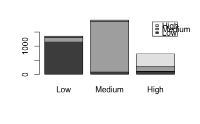

```r
barplot(table.conf, legend = T)
```

#### Gráfico de mosaico

En un gráfico de mosaico, se ubican todas las porciones en un único cuadro.

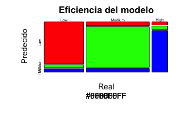

```r
mosaicplot(table.conf, main = "Eficiencia del modelo", cex = 0.5, rainbow(3), col = rainbow(3))
```

```r
summary (table.conf)
```

```
Number of cases in table: 4000
Number of factors: 2
Test for independence of all factors:
    Chisq = 4449, df = 4, p-value = 0
```